# DS 202: Midterm Exam

Polina Semenova

03/23/2022

For all of the questions below incorporate the necessary R code directy into your answers. You have 120 mins to complete this exam. At the end of the time period, upload your R Markdown file and the corresponding html file to Canvas. **Submit your results before 2pm.**

## Story County Liquor Sales

In this exam, we will study the liquor sales in Iowa. We will use two datasets, `Iowa_Liquor_Stores.csv` and `Story_County_Liquor_Sales_New.csv`, which are posted on **Canvas**. The first dataset records all the active and inactive liquor stores in Iowa as 2018/10/01. Please see the link https://data.iowa.gov/Economy/Iowa-Liquor-Stores/ykb6-ywnd for the information of the variables. You should be able to answer all of the following questions without the help of this website.

The second dataset contains the spirits purchase information of Iowa Class “E” liquor licensees by product and date of purchase from January 1, 2012 to 2018. The dataset can be used to analyze total spirits sales in Story county of individual products at the store level. Class E liquor license, for grocery stores, liquor stores, convenience stores, etc., allows commercial establishments to sell liquor for off-premises consumption in original unopened containers.

```r
library(tidyverse)
library(dplyr)
```

We will first consider the **liquor store data `Iowa_Liquor_Stores.csv`**.

```r
liquor = read.csv("Iowa_Liquor_Stores.csv")
```

### Question #1 (20 points)

- How many records are in the data set, how many variables?  
  **Answer: In the Iowa_Liquor_Stores.csv there are 1849 records and 9 variables.**

```r
str(liquor)
```

```
## 'data.frame':    1849 obs. of  9 variables:
##  $ Store        : int  2656 2657 2674 2835 2954 3013 3041 3045 3162 3354 ...
##  $ Name         : chr  "Hy-Vee Food Store / Corning" "Hy-Vee Food Store / Bedford" "Hy-Vee Food Store / Lamoni" "CVS Pharmacy #8538 / Cedar Falls" ...
##  $ Store.Status : chr  "A" "A" "A" "A" ...
##  $ Address      : chr  "300  10th St" "1604 Bent" "720 East Main" "2302 West First St" ...
##  $ City         : chr  "Corning" "Bedford" "Lamoni" "Cedar Falls" ...
##  $ State        : chr  "IA" "IA" "IA" "IA" ...
##  $ Zip.Code     : chr  "51632" "50833" "50140" "50613" ...
##  $ Store.Address: chr  "300 10th St\nCorning, IA 51632\n(40.991861, -94.731809)" "1604 Bent\nBedford, IA 50833\n(40.676171, -94.725578)" "720 East Main\nLamoni, IA 50140\n(40.623647, -93.924475)" "2302 West First St\nCedar Falls, IA 50613\n(42.539874, -92.472778)" ...
##  $ Report.Date  : chr  "10/01/2018" "10/01/2018" "10/01/2018" "10/01/2018" ...
```

- How many different cities are included in the dataset? Use `filter()` function in `dplyr` package to identify the cities outside Iowa.  
  **Answer: There are 424 different cities in the dataset. The cities that are not in Iowa are Chicago, Atlanta, Pasadena, and Colorado Springs.**

```r
length(unique(liquor$City))
```

```
## [1] 424
```

```r
liquor.noIA = liquor %>% filter(State != "IA")
unique(liquor.noIA$City)
```

```
## [1] "Chicago"          "ATLANTA"          "PASADENA"         ""
## [5] "Colorado Springs"
```

- Introduce a new logical variable `Inactive` (TRUE or FALSE) based on `Store.Status`. This variable equal to `TRUE` if `Store.Status = "I"`, otherwise, it is `FALSE`. What is the overall percentage of the inactive liquor store?  
  **Answer: The overall percentage of inactive liquor store is 16.76%**

```r
liquor = liquor %>% mutate(Inactive = if_else(liquor$Store.Status == "I", TRUE, FALSE))
(sum(liquor$Inactive) / (sum(liquor$Inactive) + sum(!liquor$Inactive))) * 100
```

```
## [1] 16.76582
```

- Use the `group_by()` and `summarise()` functions in `dplyr` package to find this percentage of inactive liquor stores for each city.

```r
liquor %>% group_by(City) %>% summarise(
  (sum(Inactive) / (sum(Inactive) + sum(!Inactive))) * 100
)
```

```
## # A tibble: 424 × 2
##    City          `(sum(Inactive)/(sum(Inactive) + sum(!Inactive))) * 100`
##    <chr>                                                            <dbl>
##  1 ""                                                                 0
##  2 "Ackley"                                                          33.3
##  3 "Adair"                                                            0
##  4 "Adel"                                                             0
##  5 "Afton"                                                            0
##  6 "Akron"                                                           50
##  7 "Albert City"                                                      0
##  8 "Albia"                                                            0
##  9 "Albion"                                                           0
## 10 "Alburnett"                                                        0
## # … with 414 more rows
```

### Question #2 (20 points)

- Create a new variable `City1` which convert `City` to a character variable.

```r
liquor = liquor %>% mutate(City1 = as.character(City))
```

- Use `filter()` function and the variable `City1` (**NOT `City`**) to select the cities `Albert City, Ames, Boone, Clarion, Clive, Dubuque, Des Moines, Garwin, Iowa City, Jefferson` from the liquor store data. Drop variable `City`.

```r
liquor %>% filter(City1 == "Albert City" | City1 == "Ames" | City1 == "Boone" | City1 == "Clarion" | City1 == "Clive" | City1 == "Dubuque" | City1 == "Des Moines" | City1 == "Garwin" | City1 == "Iowa City" | City1 == "Jefferson")
```

```
##     Store                                        Name Store.Status
## 1    2954                          Dahl's / Ingersoll            I
## 2    3738            Hartig Drug Company #4 / Dubuque            A
## 3    3872               Target Store T-0086 / Dubuque            A
## 4    3877            Target Store T-2041 / Des Moines            A
## 5    3896 Smokin' Joe's #18 Tobacco and Liquor Outlet            A
## 6    3926                 Liquor Downtown / Iowa City            I
## 7    4023                       Wal-Mart 1389 / Boone            A
## 8    4004                        Wal-Mart 4256 / Ames            A
## 9    4393                       KUM & GO #206 / Clive            A
## 10   4709                     Walgreens #12108 / Ames            A
## 11   4712                  Walgreens #11942 / Dubuque            A
## 12   4728                Walgreens #05077 / Iowa City            A
## 13   4765                Kwik Stop C-Stores / Dubuque            A
## 14   4766                    Keywest Conoco / Dubuque            A
```

[output cut: 1001 more lines]

```r
liquor = select(liquor, -5)
```

- For the 10 selected cities, create a summary dataset to record the name of the city and the number of stores in city. Change `City1` back to a factor in the summary dataset. Reorder the levels of `City1` based on the number of their liquor stores.

```r
summary.liquor = liquor %>% group_by(City1) %>% summarise(
  numberOfStores = length(Store)
)
summary.liquor$City1 = as.factor(summary.liquor$City1)

level.reorder = levels(reorder(summary.liquor$City1, summary.liquor$numberOfStores, fun = sum))

city.reorder = factor(summary.liquor$City1, levels = level.reorder)
summary.liquor$City1 = city.reorder
```

- Using ggplot2, draw a bar plot that shows the number of the liquor stores for those 10 cities. Make sure the levels of the cities are ordered appropriately (from the previous question). Comment on the result.  
  **Answer: There are a lot of cities with a small amount of stores. There are only a few cites with more than 30 liquor stores.**

[figure not shown]

```r
summary.liquor %>% ggplot(aes(x = City1)) +
  geom_bar(aes(weight = numberOfStores)) +
  coord_flip()
```

### Question #3 (15 points)

- Uuse the following code to extract the lattitude and longtitude from the variable `Store.Address`.

```
A = read.csv("Iowa_Liquor_Stores.csv", header = TRUE)
A = A %>% separate(Store.Address, into = c("Address", "Location"), sep = "\n\\(")
A = A %>% separate(Location, into = c("Latitude", "Longitude"), sep = ",") %>% select(-Address)
A = A %>% separate(Longitude, into = c("Longitude", "drop"), sep = "\\)") %>% select(-drop)
```

Explain each step of the codes. What do we use at each step to seperate lattitude and longtitude?  
**Answer: The separate statement takes the store.address and splits it into address and location at the place were \ is. Then keeps on separating, the location gets split into latitude and longitude at the comma and the address gets dropped. Then the longitude gets separated into Longitude and drop and the drop is dropped so all we are left with is the Longitude and Latitude**

- Use ggplot2, draw a scatter plot of the location of the liquor stores by the lattitude and longtitude. Note that we may need to change the format of lattitude and longtitude.

```r
A = read.csv("Iowa_Liquor_Stores.csv", header = TRUE)
A = A %>% separate(Store.Address, into = c("Address", "Location"), sep = "\n\\(")
A = A %>% separate(Location, into = c("Latitude", "Longitude"), sep = ",") %>% select(-Address)
A = A %>% separate(Longitude, into = c("Longitude", "drop"), sep = "\\)") %>% select(-drop)
```

[figure not shown]

```r
A %>% ggplot(aes(x = Latitude, y = Longitude)) +
  geom_point()
```

Now, we use the **liquor sale data `Story_County_Liquor_Sales_New.csv`**. Note that: **Don’t knit your Rmarkdown file often.** It will be slow since this dataset is large. You can run each code chuck or each line separately once the dataset is read into the environment. You can knit after everything is ready.

### Question #4 (30 points)

- Do all the variables have the right type (numeric, factor, character, etc.)? If not, which variables should be converted, and how? (Be careful to convert factor to numeric, first convert factor to character and then character to numeric.)

```r
store = read.csv("Story_County_Liquor_Sales_New.csv")
str(store)
```

```
## 'data.frame':    479752 obs. of  19 variables:
##  $ Invoice.Item.Number  : chr  "S29199000001" "S08900500035" "S06459500039" "S04846600029" ...
##  $ Date                 : chr  "11/23/2015" "11/13/2012" "07/09/2012" "04/03/2012" ...
##  $ Store.Number         : int  2501 4509 4105 4509 2500 3943 4102 4105 2501 2500 ...
##  $ Store.Name           : chr  "Hy-vee  #2 / Ames" "A J'S LIQUOR II" "Fareway Stores #426 / Nevada" "A J'S LIQUOR II" ...
##  $ Address              : chr  "640 LINCOLNWAY" "2515 CHAMBERLAIN" "1505 SOUTH B AVE" "2515 CHAMBERLAIN" ...
##  $ City                 : chr  "AMES" "AMES" "NEVADA" "AMES" ...
##  $ Zip.Code             : int  50010 50010 50201 50010 50010 50201 50010 50201 50010 50010 ...
##  $ County.Number        : int  85 85 85 85 85 85 85 85 85 85 ...
##  $ County               : chr  "Story" "Story" "Story" "Story" ...
##  $ Category             : int  NA 1081900 1041100 1032080 1012200 1081600 1011100 1071100 1022100 1012100 ...
##  $ Category.Name        : chr  "" "MISC. AMERICAN CORDIALS & LIQUEURS" "AMERICAN DRY GINS" "IMPORTED VODKA" ...
##  $ Vendor.Number        : int  255 322 434 35 260 260 260 55 395 55 ...
##  $ Vendor.Name          : chr  "Wilson Daniels Ltd." "Prestige Wine and Spirits Group" "Luxco-St Louis" "Bacardi U.S.A., Inc." ...
##  $ Item.Number          : int  297 75210 31658 34433 6196 67267 25608 57148 89230 11936 ...
##  $ Item.Description     : chr  "Templeton Rye w/Flask" "Kinky Liqueur" "Paramount Gin" "Grey Goose Vodka" ...
##  $ Pack                 : int  6 6 6 12 6 12 6 6 6 12 ...
##  $ Sale..Dollars.       : chr  "651.36" "180.00" "21.30" "323.52" ...
##  $ Volume.Sold..Liters. : chr  "18.00" "9.00" "3.50" "9.00" ...
##  $ Volume.Sold..Gallons.: num  4.755 2.378 0.925 2.378 0.198 ...
```

```r
store$Sale..Dollars. = as.numeric(store$Sale..Dollars, na.rm = TRUE)
store$Volume.Sold..Liters. = as.numeric(store$Volume.Sold..Liters., na.rm = TRUE)
store$City = as.factor(store$City)
store$County = as.factor(store$County)
store$Category.Name = as.factor(store$Category.Name)
str(store)
```

```
## 'data.frame':    479752 obs. of  19 variables:
##  $ Invoice.Item.Number  : chr  "S29199000001" "S08900500035" "S06459500039" "S04846600029" ...
##  $ Date                 : chr  "11/23/2015" "11/13/2012" "07/09/2012" "04/03/2012" ...
##  $ Store.Number         : int  2501 4509 4105 4509 2500 3943 4102 4105 2501 2500 ...
##  $ Store.Name           : chr  "Hy-vee  #2 / Ames" "A J'S LIQUOR II" "Fareway Stores #426 / Nevada" "A J'S LIQUOR II" ...
##  $ Address              : chr  "640 LINCOLNWAY" "2515 CHAMBERLAIN" "1505 SOUTH B AVE" "2515 CHAMBERLAIN" ...
##  $ City                 : Factor w/ 16 levels "Ames","AMES",..: 2 2 11 2 2 11 2 11 2 2 ...
##  $ Zip.Code             : int  50010 50010 50201 50010 50010 50201 50010 50201 50010 50010 ...
##  $ County.Number        : int  85 85 85 85 85 85 85 85 85 85 ...
##  $ County               : Factor w/ 2 levels "Story","STORY": 1 1 1 1 1 1 1 1 1 1 ...
##  $ Category             : int  NA 1081900 1041100 1032080 1012200 1081600 1011100 1071100 1022100 1012100 ...
##  $ Category.Name        : Factor w/ 126 levels "","100 PROOF VODKA",..: 1 82 15 71 98 123 29 9 115 34 ...
##  $ Vendor.Number        : int  255 322 434 35 260 260 260 55 395 55 ...
##  $ Vendor.Name          : chr  "Wilson Daniels Ltd." "Prestige Wine and Spirits Group" "Luxco-St Louis" "Bacardi U.S.A., Inc." ...
##  $ Item.Number          : int  297 75210 31658 34433 6196 67267 25608 57148 89230 11936 ...
##  $ Item.Description     : chr  "Templeton Rye w/Flask" "Kinky Liqueur" "Paramount Gin" "Grey Goose Vodka" ...
##  $ Pack                 : int  6 6 6 12 6 12 6 6 6 12 ...
##  $ Sale..Dollars.       : num  651.4 180 21.3 323.5 51.7 ...
##  $ Volume.Sold..Liters. : num  18 9 3.5 9 0.75 2 10.5 21 1.5 2.25 ...
##  $ Volume.Sold..Gallons.: num  4.755 2.378 0.925 2.378 0.198 ...
```

- Check the variables `County` and `City`. Several of them should be same city or the same county but regarded as different levels in the dataset. Fix them.

```r
levels(store$City)
```

```
##  [1] "Ames"       "AMES"       "CAMBRIDGE"  "Colo"       "COLO"
##  [6] "Huxley"     "HUXLEY"     "Maxwell"    "MAXWELL"    "Nevada"
## [11] "NEVADA"     "Roland"     "Slater"     "SLATER"     "Story City"
## [16] "STORY CITY"
```

```r
levels(store$City)[1] = levels(store$City)[2]
levels(store$City)[3] = levels(store$City)[4]
levels(store$City)[5] = levels(store$City)[6]
levels(store$City)[5] = levels(store$City)[6]
levels(store$City)[6] = levels(store$City)[7]
levels(store$City)[8] = levels(store$City)[9]
levels(store$City)[9] = levels(store$City)[10]
levels(store$City)
```

```
## [1] "AMES"       "CAMBRIDGE"  "COLO"       "Huxley"     "MAXWELL"
## [6] "NEVADA"     "Roland"     "SLATER"     "STORY CITY"
```

- extract year, month and day from the variable `Date`.

```r
store = store %>% separate(Date, into = c("month", "day", "year"), sep = "/")
```

- Use the `group_by()` and `summarise()` functions in `dplyr` package to obtain a summarized dataset of total `Volume.Sold..Gallons.` and `Sale..Dollars.` for different combinations of `month`, `year` and `City`. Name this data as `Liquor.Sale.Summary1` with variable names `total.volume` and `total.sale`. (The City should be corrected from the previous questions, and `Sale..Dollars.` should be converted to a numeric variable.)

```r
Liquor.Sale.Summary1 = store %>% group_by(month, day, year, City) %>% summarise(
  total.volume = sum(Volume.Sold..Gallons.),
  total.sale = sum(Sale..Dollars.)
)
```

- Use ggplot2, based on `Liquor.Sale.Summary1`, draw a histogram for the distribution of `total.volume`, facet by cities. Does the result surprise you? Comment.  
  **Answer: Yes, the result is surprising because the highest value is in Ames. The rest of the cities is very small incomparison.**

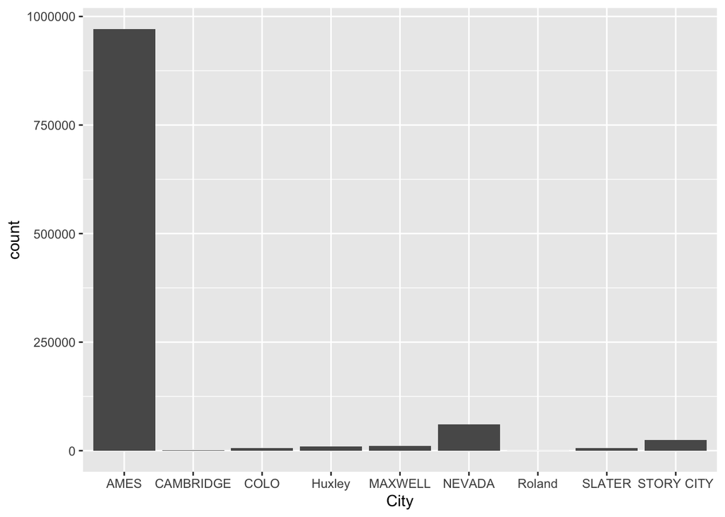

```r
Liquor.Sale.Summary1 %>% ggplot(aes(x = City)) +
  geom_bar(aes(weight = total.volume))
```

- Use barplot in ggplot2, based on `Liquor.Sale.Summary1`, compare the `total.sale` between different months, facet by cities (use `scales = "free"` in facet). Color the bar by `years`. Comment on the result.

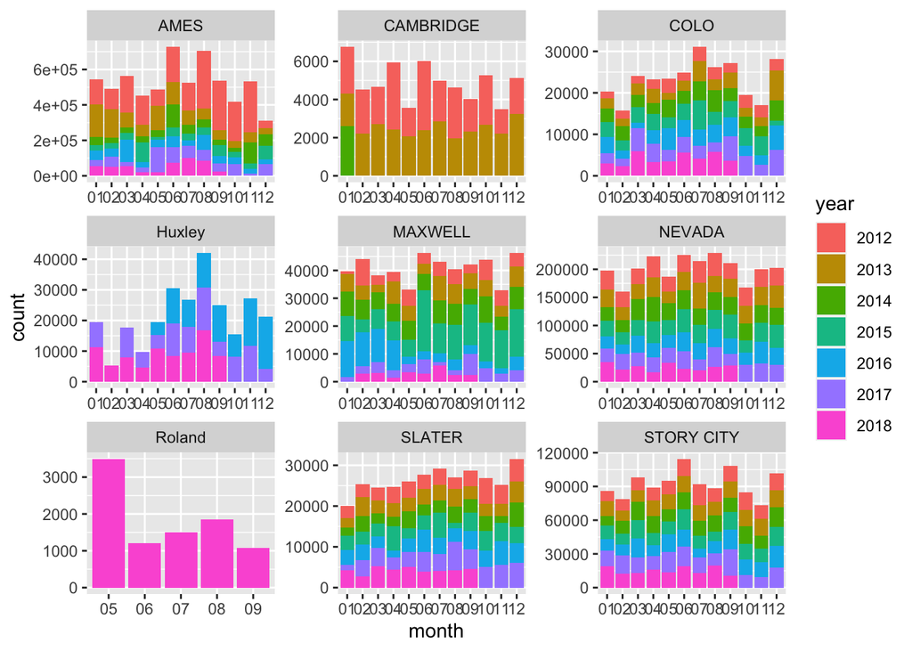

```r
Liquor.Sale.Summary1 %>% ggplot(aes(x = month, fill = year)) +
  geom_bar(aes(weight = total.sale)) +
  facet_wrap(~City, scales = "free")
```

### Question #5 (15 points)

- Use the corrected liquor sale data, first only select the stores in Ames, then summarize the total `Volume.Sold..Gallons.` and `Sale..Dollars.` for each combination of month, year and Store. Call the data `Liquor.Sale.Summary2`.

```r
Liquor.Sale.Summary2 = store %>% filter(City == "AMES")
Liquor.Sale.Summary2 = Liquor.Sale.Summary2 %>% group_by(month, year, Store.Name) %>% summarise(
  total.volume = sum(Volume.Sold..Gallons.),
  total.sale = sum(Sale..Dollars.)
)
```

```r
winningStores = Liquor.Sale.Summary2 %>% filter(year == 2016)
winningStores = winningStores %>% group_by(month) %>% summarise(
  winner = Store.Name[which.max(total.sale)]
)
```

- For years 2016 and 2017, use ggplot2, draw a scatter plot for the trend of total sale over month. Please seperate the trend for each store. You need to use `color` and `facet` options in ggplot2.

```r
store.2016.2017 = store %>% filter(year == 2016 | year == 2017)
store.2016.2017 = store.2016.2017 %>% group_by(month, year, day, Store.Name) %>% summarise(
  total.volume = sum(Volume.Sold..Gallons.),
  total.sale = sum(Sale..Dollars.)
)
```

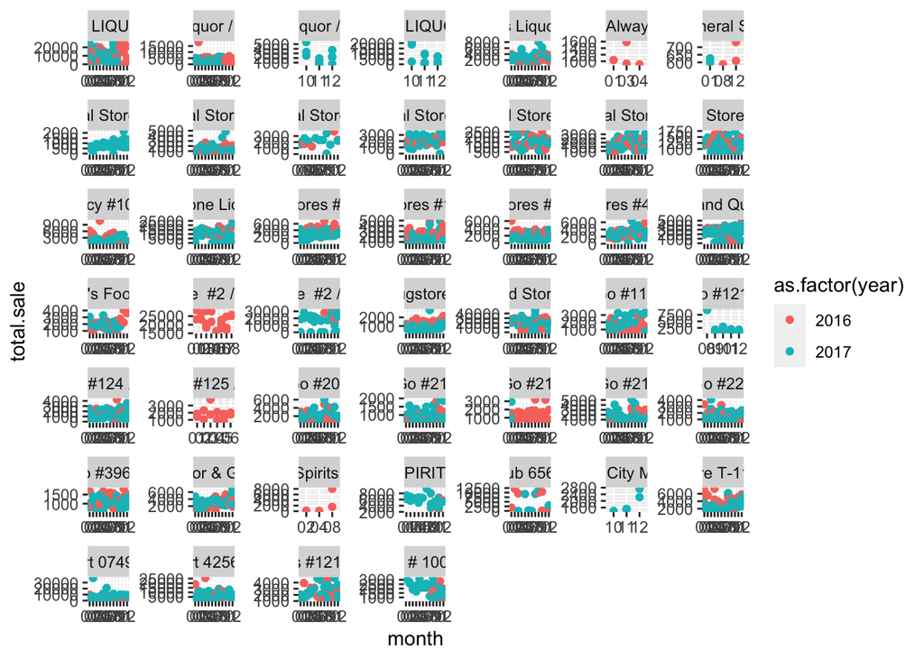

```r
store.2016.2017 %>% ggplot(aes(x = month, y = total.sale, color = as.factor(year))) +
  geom_point() +
  facet_wrap(~Store.Name, scales = "free")
```